# Healthcare Insurance Analysis

Amar Dunham

# Outline

The goal of this project was to generate a statistically useful model that best predicts healthcare insurance charges through implementation of different regression techniques studied from a statistical data analysis course. This was done by looking at a healthcare dataset and examining significant variables contributing to insurance charges and then building various multiple linear regression models to determine the best fitted.

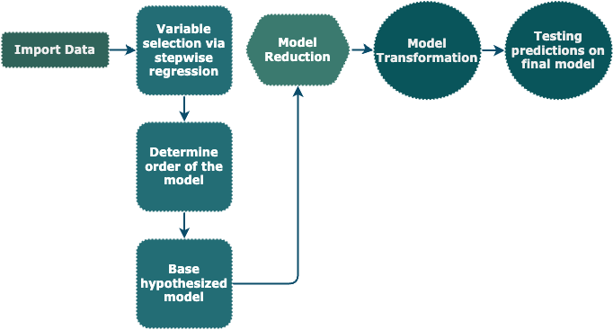

```r
# Functions

anova_hconclusion <- function(reduced, complete, alpha){
  #runs a nested F-test on the models of choice
    #reduced = model with the least terms; more parsimonious model
    #complete = model with the most terms
    #alpha = criteria to determine if the hypothesis claim is rejected or supported

  #checking if the reduced model class is a list of models
  #the argument input: list(list('modelname' = model), etc)
  if (class(reduced) == 'list'){

    #look at each model in the list individually
    for (m in seq_along(reduced)){

      #calculate p-value from the anova test
      pval <- anova(reduced[[m]][[1]], complete)$"Pr(>F)"
      pval <- pval[2]

      #test p-value and draw conclusion
      if (pval > alpha){

        print(glue('Complete: {deparse(substitute(complete))}
                    Reduced: {names(reduced[m][[1]])}
                    anova({names(reduced[m][[1]])}, {deparse(substitute(complete))})
                    Global F p-value: {signif(pval, 4)}
                    Conclusion: fail to reject the null, all extra beta terms in complete model are not significant for predicting y
                    Model to use: {names(reduced[m][[1]])}'))
        cat('\n') #spacing between outputs
      }
      else{
        print(glue('Complete: {deparse(substitute(complete))}
                    Reduced: {names(reduced[m][[1]])}
                    anova({names(reduced[m][[1]])}, {deparse(substitute(complete))})
                    Global F p-value: {signif(pval, 4)}
                    Conclusion: reject the null, at least one extra beta term in complete model is significant for predicting y
                    Model to use: {deparse(substitute(complete))}'))
        cat('\n')
      }
    }
  }

  #checking if the reduced model class is linear, only one model
  if (class(reduced) == 'lm'){
    pval <- anova(reduced, complete)$"Pr(>F)"
    pval <- pval[2]

    if (pval > alpha){
      print(glue('Complete: {deparse(substitute(complete))}
                    Reduced: {deparse(substitute(reduced))}
                    anova({deparse(substitute(reduced))}, {deparse(substitute(complete))})
                    Global F p-value: {signif(pval, 4)}
                    Conclusion: fail to reject the null, all extra beta terms in complete model are not significant for predicting y
                    Model to use: {deparse(substitute(reduced))}'))
    }
    else{
      print(glue('Complete: {deparse(substitute(complete))}
                    Reduced: {deparse(substitute(reduced))}
                    anova({deparse(substitute(reduced))}, {deparse(substitute(complete))})
                    Global F p-value: {signif(pval, 4)}
                    Conclusion: reject the null, at least one extra beta term in complete model is significant for predicting y
                    Model to use: {deparse(substitute(complete))}'))
    }
  }
}

cv <- function(model){
  #calculates the coefficient of variation: (residual error/mean of y) *100
  print((summary(model)$sigma/mean(insurance$charges)) * 100)
}
```

# Data

The data comes from the [“Healthcare Insurance”](https://www.kaggle.com/datasets/willianoliveiragibin/healthcare-insurance/data) dataset found on Kaggle which comprises of 1,338 observations representing insured individuals:

```r
insurance <- read.csv("insurance.csv")
head(insurance, 5)
```

```
##   age    sex    bmi children smoker    region   charges
## 1  19 female 27.900        0    yes southwest 16884.924
## 2  18   male 33.770        1     no southeast  1725.552
## 3  28   male 33.000        3     no southeast  4449.462
## 4  33   male 22.705        0     no northwest 21984.471
## 5  32   male 28.880        0     no northwest  3866.855
```

# Analysis

## Stepwise Regression

Before creating models, stepwise regression was applied to see which variables are important predictors for the dependent variable. Specifically, forward stepwise regression was used which added the variable term to the model equation if the variable term’s Akaike Information Criterion was the smallest (AIC). The AIC acts as a measure of quality for the statistical models, so using the AIC in this regression procedure means that the lowest AIC value for a variable term would make it important for adding to the model. Although it may not seem like stepwise regression should be used here since there are not many features, it is one of the useful variable screening method practices if there were:

```r
min.model = lm(charges ~1, data = insurance) #starts with the intercept
step(min.model,
     scope = (~age + sex + bmi + children + smoker + region), #all variables of interest
     data = insurance,
     direction = 'forward') #adds the variable with the smallest AIC to the model after each iteration
```

```
## Start:  AIC=25160.18
## charges ~ 1
##
##            Df  Sum of Sq        RSS   AIC
## + smoker    1 1.2152e+11 7.4554e+10 23868
## + age       1 1.7530e+10 1.7854e+11 25037
## + bmi       1 7.7134e+09 1.8836e+11 25108
## + children  1 9.0660e+08 1.9517e+11 25156
## + region    3 1.3008e+09 1.9477e+11 25157
## + sex       1 6.4359e+08 1.9543e+11 25158
## <none>                   1.9607e+11 25160
##
## Step:  AIC=23868.38
## charges ~ smoker
##
##            Df  Sum of Sq        RSS   AIC
## + age       1 1.9928e+10 5.4626e+10 23454
## + bmi       1 7.4856e+09 6.7069e+10 23729
## + children  1 7.5272e+08 7.3802e+10 23857
## <none>                   7.4554e+10 23868
## + sex       1 1.4213e+06 7.4553e+10 23870
## + region    3 1.0752e+08 7.4447e+10 23872
##
## Step:  AIC=23454.24
## charges ~ smoker + age
##
##            Df  Sum of Sq        RSS   AIC
## + bmi       1 5112896646 4.9513e+10 23325
## + children  1  459283727 5.4167e+10 23445
## <none>                   5.4626e+10 23454
## + sex       1    2225509 5.4624e+10 23456
## + region    3  138426748 5.4488e+10 23457
##
## Step:  AIC=23324.76
## charges ~ smoker + age + bmi
##
##            Df Sum of Sq        RSS   AIC
## + children  1 434769398 4.9078e+10 23315
## + region    3 232012208 4.9281e+10 23324
## <none>                  4.9513e+10 23325
## + sex       1   3942912 4.9509e+10 23327
##
## Step:  AIC=23314.96
## charges ~ smoker + age + bmi + children
##
##          Df Sum of Sq        RSS   AIC
## + region  3 233200844 4.8845e+10 23315
## <none>                4.9078e+10 23315
## + sex     1   5486063 4.9073e+10 23317
##
## Step:  AIC=23314.58
## charges ~ smoker + age + bmi + children + region
##
##        Df Sum of Sq        RSS   AIC
## <none>              4.8845e+10 23315
## + sex   1   5716429 4.8840e+10 23316
```

```
##
## Call:
## lm(formula = charges ~ smoker + age + bmi + children + region,
##     data = insurance)
##
## Coefficients:
##     (Intercept)        smokeryes              age              bmi
##        -11990.3          23836.3            257.0            338.7
##        children  regionnorthwest  regionsoutheast  regionsouthwest
##           474.6           -352.2          -1034.4           -959.4
```

From the results of the regression, it appears that `sex` is the only term that is not important for predicting healthcare insurance costs–the procedure finishes once the threshold AIC used from the previous smallest variable term does not contain any terms smaller than it. However, I decided to add `sex` in the proceeding model formations because it does seem like a variable of interest in this analysis since there are cases of gender bias in areas such as insurance. This reveals one caveat of stepwise regression in that there could be a variable of interest that is regarded as unimportant in which intuition would need to come into play.

## Visualizing Quantitative and Dependent Variable Relationships

The relationships between the quantitative and the dependent variables were visualized in order to determine which ordered term the model should use. I chose to do this before randomly building the theoretical model so that I could have more leverage in creating a model that is on the path of generating good predictions from its precise fitted line. To note, this was only done to the quantitative variables because it would be meaningless to assign higher orders to qualitative variables:

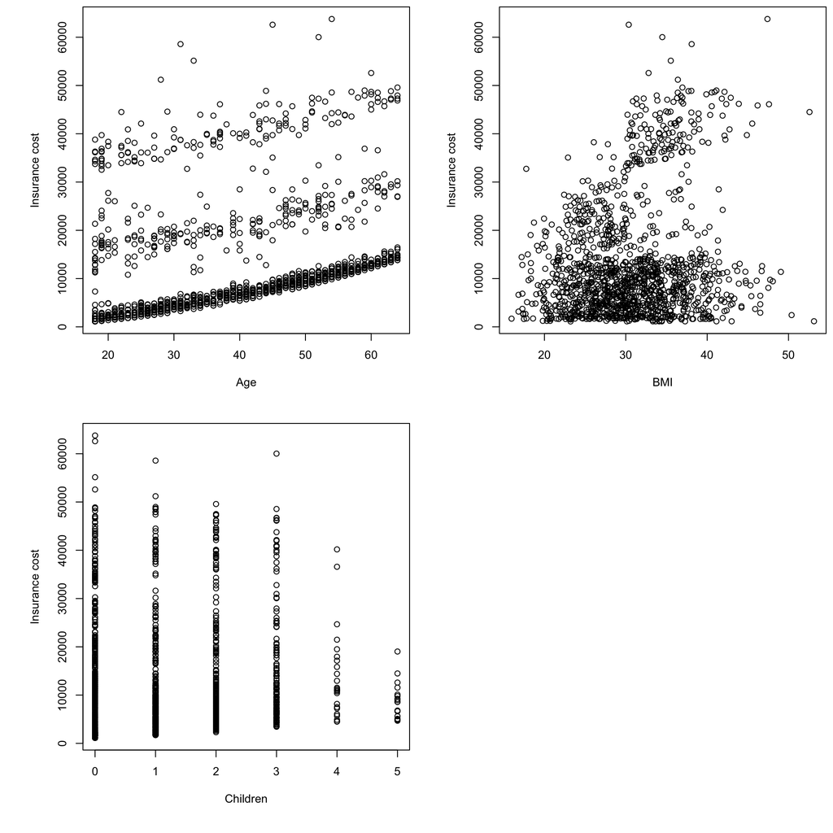

```r
par(mfrow = c(2, 2), mar = c(6, 6, 0.5, 0.5))
plot(insurance$age, insurance$charges, xlab = 'Age', ylab = 'Insurance cost')
plot(insurance$bmi, insurance$charges, xlab = 'BMI', ylab = 'Insurance cost')
plot(insurance$children, insurance$charges, xlab = 'Children', ylab = 'Insurance cost')
```

In the graphs, it appears that `age` and `children` look curvilinear while `BMI` looks linear which means that a second-order model should be the highest order used for the model formations.

## Building a Hypothesized Model

In figuring out the highest order, I then started with a base model with all possible combinations for a second-order complete linear model:

$E(y) = \beta_{0} + \beta_{1}x_{1} + \beta_{2}x_{2} + \beta_{3}x_{3} + \beta_{4}x_{1}x_{2} + \beta_{5}x_{1}x_{3} + \beta_{6}x_{2}x_{3} + \beta_{7}x_{1}^2 + \beta_{8}x_{2}^2 + \beta_{9}x_{4} + \beta_{10}x_{5} + \beta_{11}x_{6} + \beta_{12}x_{7} + \beta_{13}x_{8} + \\ \hspace{12 mm} \\ \hspace{12 mm} \beta_{14}x_{4}x_{5} + \beta_{15}x_{4}x_{6} + \beta_{16}x_{4}x_{7} + \beta_{17}x_{4}x_{8} + \beta_{18}x_{5}x_{6} + \beta_{19}x_{5}x_{7} + \beta_{20}x_{5}x_{8} + \\ \hspace{12 mm} \\ \hspace{12 mm} \beta_{21}x_{1}x_{4} + \beta_{22}x_{1}x_{5} + \beta_{23}x_{1}x_{6} + \beta_{24}x_{1}x_{7} + \beta_{25}x_{1}x_{8} + \beta_{26}x_{1}x_{4}x_{5} + \beta_{27}x_{1}x_{4}x_{6} + \beta_{28}x_{1}x_{4}x_{7} + \beta_{29}x_{1}x_{4}x_{8} + \beta_{30}x_{1}x_{5}x_{6} + \beta_{31}x_{1}x_{5}x_{7} + \beta_{32}x_{1}x_{5}x_{8} + \\ \hspace{30 mm} ⋮ \\ \hspace{12 mm} \beta_{105}x_{2}^2x_{4} + \beta_{106}x_{2}^2x_{5} + \beta_{107}x_{2}^2x_{6} + \beta_{108}x_{2}^2x_{7} + \beta_{109}x_{2}^2x_{8} + \beta_{110}x_{2}^2x_{4}x_{5} + \beta_{111}x_{2}^2x_{4}x_{6} + \beta_{112}x_{2}^2x_{4}x_{7} + \beta_{113}x_{2}^2x_{4}x_{8} + \beta_{114}x_{2}^2x_{5}x_{6} + \beta_{115}x_{2}^2x_{5}x_{7} + \beta_{116}x_{2}^2x_{5}x_{8}$

where,

$x_{1} = \text{age}$ $x_{2} = \text{children}$ $x_{3} = \text{BMI}$

$x_{4}\text{(sex)} = \begin{cases} 1 &\quad \text{male}\\ 0 &\quad \text{female} \end{cases}$ $x_{5}\text{(smoker)} = \begin{cases} 1 &\quad \text{yes}\\ 0 &\quad \text{no} \end{cases}$

$x_{6}\text{(region)} = \begin{cases} 1 &\quad \text{Northwest}\\ 0 &\quad \text{other} \end{cases}$ $x_{7}\text{(region)} = \begin{cases} 1 &\quad \text{Southest}\\ 0 &\quad \text{other} \end{cases}$ $x_{8}\text{(region)} = \begin{cases} 1 &\quad \text{Southwest}\\ 0 &\quad \text{other} \end{cases}$

$x_{6} = x_{7} = x_{8} = \text{Northeast}$

## Reducing the Base Model

Following the base model I decided which variables and interactions to include and/or exclude from a series of nested F-tests. The process of selecting the variables and interactions were methodical in regards to the terms being quadratic or having different combinations of interactions between quadratic, qualitative, and quantitative variables, not in regards to the meaning of the variables to each other.

When conducting the nested F-tests, I first started with the complete model which was the base model and the reduced models which were the models nested within the complete model but with smaller terms. An anova test was then run between the complete model and each individual reduced model to find the p-value. For the hypotheses, the null was that all extra beta terms in the complete model equal zero meaning that those terms are not significant for predicting the dependent variable and the alternative was that at least one of those beta terms in the complete model does not equal zero meaning that the term is significant.

$$H_{0}: \text{all
added}~\beta_{i}~\text{terms in complete model} = 0$$
$$H_{a}: \text{at least one}~\beta_{i}~\text{in the
added terms in complete model} \neq 0$$

By evaluating the p-value, if it was smaller than a specified alpha value, it would reject the null and support the claim that the complete model should be used. If it was larger, it would fail to reject the null and reveal that there’s insufficient evidence to support those extra beta terms being significant meaning that the reduced model should be used. If the reduced model was used, the procedure was repeated to see if that model could be further reduced, this time with the reduced model acting as the complete model for which the terms would be eliminated from.

```r
# First nested F-tests
model_list <- list(list('model2' = model2), #removes quadratic terms
                   list('model3' = model3), #removes quantitative*qualitative interactions
                   list('model4' = model4)) #removes quadratic*qualitative interactions
anova_hconclusion(reduced = model_list, complete = model1, alpha = 0.05)
```

```
## Complete: model1
## Reduced: model2
## anova(model2, model1)
## Global F p-value: 0.02912
## Conclusion: reject the null, at least one extra beta term in complete model is significant for predicting y
## Model to use: model1
##
## Complete: model1
## Reduced: model3
## anova(model3, model1)
## Global F p-value: 1.853e-81
## Conclusion: reject the null, at least one extra beta term in complete model is significant for predicting y
## Model to use: model1
##
## Complete: model1
## Reduced: model4
## anova(model4, model1)
## Global F p-value: 0.7818
## Conclusion: fail to reject the null, all extra beta terms in complete model are not significant for predicting y
## Model to use: model4
```

```r
# Second nested F-tests
anova_hconclusion(reduced = model5, #removes qualitative*qualitative interactions
                  complete = model4, alpha = 0.05)
```

```
## Complete: model4
## Reduced: model5
## anova(model5, model4)
## Global F p-value: 0.3925
## Conclusion: fail to reject the null, all extra beta terms in complete model are not significant for predicting y
## Model to use: model5
```

```r
# Third nested F-tests
model_list <- list(list('model6' = model6), #removes quantitative*quantitative interactions
                   list('model7' = model7)) #removes quadratic terms
anova_hconclusion(reduced = model_list, complete = model5, alpha = 0.05)
```

```
## Complete: model5
## Reduced: model6
## anova(model6, model5)
## Global F p-value: 0.4635
## Conclusion: fail to reject the null, all extra beta terms in complete model are not significant for predicting y
## Model to use: model6
##
## Complete: model5
## Reduced: model7
## anova(model7, model5)
## Global F p-value: 0.003486
## Conclusion: reject the null, at least one extra beta term in complete model is significant for predicting y
## Model to use: model5
```

After the tests, model 6 appears to be the best model which removes the quadratic to qualitative, qualitative to qualitative, and quantitative to quantitative interactions. Looking at the `summary()` output can further explain the performance of this model to see if there should be any other changes to it:

```r
summary(model6)
```

```
##
## Call:
## lm(formula = charges ~ age + children + bmi + I(age^2) + I(children^2) +
##     sex + smoker + region + age * sex + age * smoker + age *
##     region + children * sex + children * smoker + children *
##     region + bmi * sex + bmi * smoker + bmi * region, data = insurance)
##
## Residuals:
##      Min       1Q   Median       3Q      Max
## -13142.2  -1810.7  -1202.5   -466.7  30475.1
##
## Coefficients:
##                            Estimate Std. Error t value Pr(>|t|)
## (Intercept)               2.149e+03  2.013e+03   1.068 0.285896
## age                      -9.037e+01  6.846e+01  -1.320 0.187064
## children                  1.281e+03  3.778e+02   3.391 0.000717 ***
## bmi                       9.340e+01  5.081e+01   1.838 0.066265 .
## I(age^2)                  3.987e+00  8.199e-01   4.863  1.3e-06 ***
## I(children^2)            -9.778e+01  8.223e+01  -1.189 0.234585
## sexmale                  -1.285e+03  1.495e+03  -0.859 0.390228
## smokeryes                -2.025e+04  1.848e+03 -10.954  < 2e-16 ***
## regionnorthwest          -1.281e+03  2.214e+03  -0.579 0.562826
## regionsoutheast           2.772e+03  2.101e+03   1.319 0.187236
## regionsouthwest           1.480e+02  2.133e+03   0.069 0.944695
## age:sexmale               1.716e+01  1.892e+01   0.907 0.364699
## age:smokeryes            -7.437e+00  2.368e+01  -0.314 0.753485
## age:regionnorthwest       1.579e+01  2.712e+01   0.582 0.560470
## age:regionsoutheast       5.329e+01  2.637e+01   2.021 0.043449 *
## age:regionsouthwest       4.113e+01  2.740e+01   1.501 0.133573
## children:sexmale         -1.964e+02  2.203e+02  -0.892 0.372809
## children:smokeryes       -3.802e+02  2.840e+02  -1.339 0.180854
## children:regionnorthwest  2.361e+02  3.206e+02   0.736 0.461604
## children:regionsoutheast -2.244e+02  3.111e+02  -0.721 0.470770
## children:regionsouthwest -3.842e+02  3.072e+02  -1.250 0.211340
## bmi:sexmale               1.198e+01  4.395e+01   0.273 0.785183
## bmi:smokeryes             1.460e+03  5.282e+01  27.647  < 2e-16 ***
## bmi:regionnorthwest      -8.034e+00  6.945e+01  -0.116 0.907927
## bmi:regionsoutheast      -1.859e+02  6.038e+01  -3.078 0.002127 **
## bmi:regionsouthwest      -8.776e+01  6.651e+01  -1.320 0.187229
## ---
## Signif. codes:  0 '***' 0.001 '**' 0.01 '*' 0.05 '.' 0.1 ' ' 1
##
## Residual standard error: 4789 on 1312 degrees of freedom
## Multiple R-squared:  0.8465, Adjusted R-squared:  0.8436
## F-statistic: 289.5 on 25 and 1312 DF,  p-value: < 2.2e-16
```

```r
# Coefficient of Variation
(summary(model6)$sigma/mean(insurance$charges)) * 100
```

```
## [1] 36.08715
```

## Model Transformation

The high residual standard error suggests that the residuals of the model should be looked at to see if any assumptions on the error term are violated:

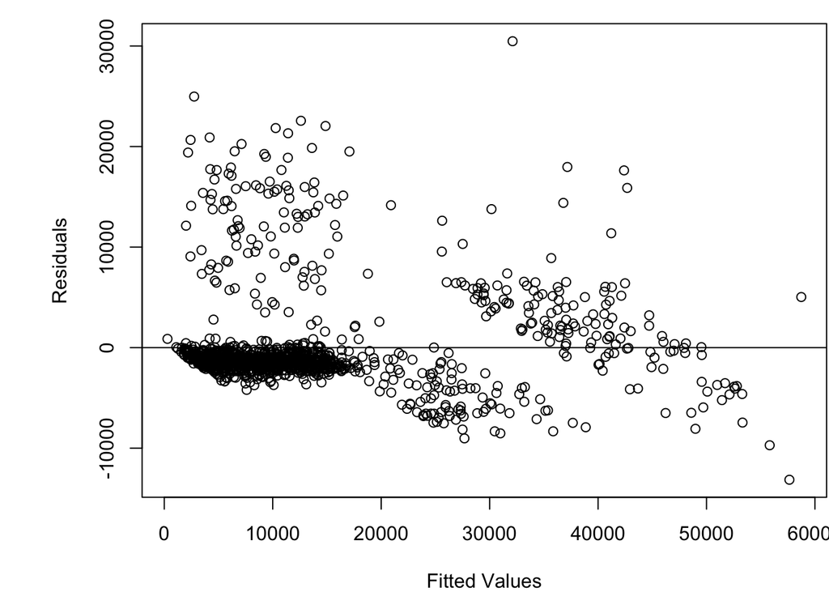

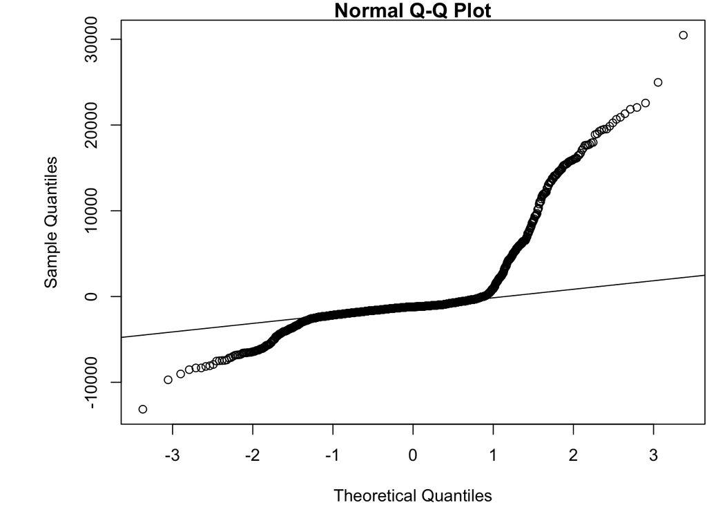

```r
par(mar = c(4, 6, 1, 0.1))

# Constant variance assumption
yhat_6 <- predict(model6)
plot(yhat_6, model6$residuals, xlab = 'Fitted Values', ylab = 'Residuals')
abline(h = 0)

# Normality assumption
qqnorm(model6$residuals)
qqline(model6$residuals)
```

Here I only tested two assumptions for the residual errors: constant variance and normality assumptions. In the first plot, the constant variance assumption is violated as the residuals do not look to be equally distributed. The second plot shows that the residuals look rightly skewed, violating the normality assumption. One way to resolve this issue is to apply a variance-stabilizing transformation on the residuals which would help with the heteroscedastic errors and in turn could help pass the normality assumption.

A natural log transformation was applied to the model as the shape of the residual distribution in the first plot seems somewhat cone-shaped. With this new model, I viewed the summary output again to see the performance and residuals of this model:

$ln(y) = \beta_{0} + \beta_{1}x_{1} + \beta_{2}x_{2} + \beta_{3}x_{3} + \beta_{4}x_{1}^2 + \beta_{5}x_{2}^2 + \beta_{6}x_{4} + \beta_{7}x_{5} + \beta_{8}x_{6} + \beta_{9}x_{7} + \beta_{10}x_{8} + \\ \hspace{12 mm} \\ \hspace{12 mm} \beta_{11}x_{1}x_{4} + \beta_{12}x_{1}x_{5} + \beta_{13}x_{1}x_{6} + \beta_{14}x_{1}x_{7} + \beta_{15}x_{1}x_{8} + \\ \hspace{12 mm} \\ \hspace{12 mm} \beta_{16}x_{2}x_{4} + \beta_{17}x_{2}x_{5} + \beta_{18}x_{2}x_{6} + \beta_{19}x_{2}x_{7} + \beta_{20}x_{2}x_{8} + \\ \hspace{12 mm} \\ \hspace{12 mm} \beta_{21}x_{3}x_{4} + \beta_{22}x_{3}x_{5} + \beta_{23}x_{3}x_{6} + \beta_{24}x_{3}x_{7} + \beta_{25}x_{3}x_{8} + \epsilon$

```r
summary(model8)
```

```
##
## Call:
## lm(formula = log(charges) ~ age + children + bmi + I(age^2) +
##     I(children^2) + sex + smoker + region + age * sex + age *
##     smoker + age * region + children * sex + children * smoker +
##     children * region + bmi * sex + bmi * smoker + bmi * region,
##     data = insurance)
##
## Residuals:
##      Min       1Q   Median       3Q      Max
## -0.55059 -0.16092 -0.08576  0.00364  2.48027
##
## Coefficients:
##                            Estimate Std. Error t value Pr(>|t|)
## (Intercept)               6.889e+00  1.581e-01  43.572  < 2e-16 ***
## age                       5.034e-02  5.379e-03   9.359  < 2e-16 ***
## children                  1.663e-01  2.968e-02   5.604 2.55e-08 ***
## bmi                       8.261e-03  3.992e-03   2.069 0.038700 *
## I(age^2)                 -1.932e-04  6.441e-05  -2.999 0.002756 **
## I(children^2)            -1.397e-02  6.460e-03  -2.163 0.030750 *
## sexmale                  -3.617e-01  1.175e-01  -3.078 0.002125 **
## smokeryes                 1.379e+00  1.452e-01   9.495  < 2e-16 ***
## regionnorthwest           5.374e-02  1.739e-01   0.309 0.757408
## regionsoutheast           8.809e-02  1.650e-01   0.534 0.593607
## regionsouthwest          -1.530e-01  1.676e-01  -0.913 0.361605
## age:sexmale               4.673e-03  1.487e-03   3.143 0.001711 **
## age:smokeryes            -3.358e-02  1.860e-03 -18.051  < 2e-16 ***
## age:regionnorthwest       2.231e-03  2.130e-03   1.047 0.295194
## age:regionsoutheast       7.194e-03  2.071e-03   3.473 0.000531 ***
## age:regionsouthwest       6.697e-03  2.153e-03   3.111 0.001906 **
## children:sexmale          1.339e-02  1.730e-02   0.774 0.439303
## children:smokeryes       -1.235e-01  2.231e-02  -5.534 3.77e-08 ***
## children:regionnorthwest  1.127e-02  2.519e-02   0.447 0.654724
## children:regionsoutheast -1.460e-02  2.444e-02  -0.598 0.550225
## children:regionsouthwest -1.591e-02  2.413e-02  -0.659 0.509910
## bmi:sexmale               2.765e-03  3.453e-03   0.801 0.423405
## bmi:smokeryes             5.231e-02  4.149e-03  12.606  < 2e-16 ***
## bmi:regionnorthwest      -7.505e-03  5.456e-03  -1.375 0.169220
## bmi:regionsoutheast      -1.616e-02  4.744e-03  -3.408 0.000675 ***
## bmi:regionsouthwest      -8.329e-03  5.225e-03  -1.594 0.111153
## ---
## Signif. codes:  0 '***' 0.001 '**' 0.01 '*' 0.05 '.' 0.1 ' ' 1
##
## Residual standard error: 0.3762 on 1312 degrees of freedom
## Multiple R-squared:  0.8357, Adjusted R-squared:  0.8326
## F-statistic:   267 on 25 and 1312 DF,  p-value: < 2.2e-16
```

In this summary output the transformed model is useful for predicting insurance charges from the global F-test p-value, about 83% of sample variation in insurance charges is explained by the model, and the residual standard error is relatively small having the CV value at 4.13%. In the previous untransformed model, the residual standard error represents the dollar amount of insurance charges, but here in the transformed model it represents the percentage of the insurance charges. So to convert it back to the dollar amount, this calculation was applied:

```r
# Converting insurance charge percentage to insurance charge cost (in thousands of dollars)
(exp(2 * 0.3762) - 1) * 1000
```

```
## [1] 1122.087
```

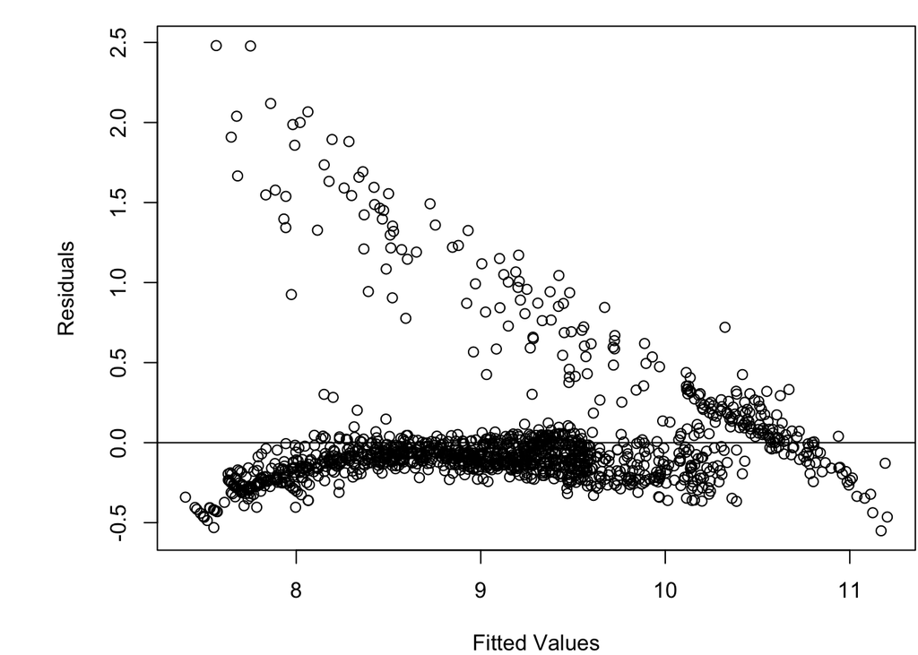

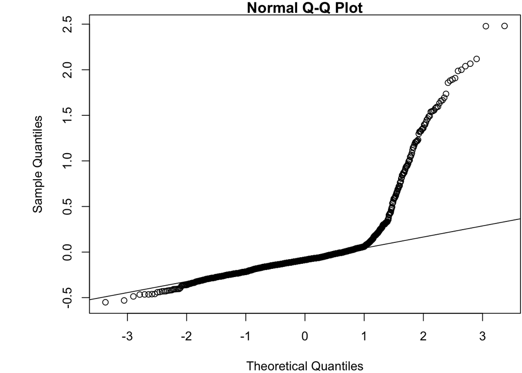

```r
par(mar = c(4, 6, 1, 0.1))

# Constant variance assumption
yhat_8 <- predict(model8)
plot(yhat_8, model8$residuals, xlab = 'Fitted Values', ylab = 'Residuals')
abline(h = 0)

# Normality assumption
qqnorm(model8$residuals)
qqline(model8$residuals)
```

And for the residuals of this model, they appear to follow the assumptions of constant variance and normality as the first plot has a cluster of residuals equally distributed and the second plot shows the residuals normally distributed. However, some of the residuals for both plots cause the assumptions to be violated as they make the overall residuals either heteroscedastic or rightly skewed. This issue may be attributed with outliers in the original data. Since this model has a relatively smaller residual standard error than the previous models, I decided to test the predictions with this model despite its residuals not following its assumptions.

## Testing Predictions

With the information gathered, I concluded that the natural log transformed model was the best statistically useful model to use for prediction–a second-order multiplicative linear regression model with quantitative to qualitative interaction:

$ln(y) = \beta_{0} + \beta_{1}x_{1} + \beta_{2}x_{2} + \beta_{3}x_{3} + \beta_{4}x_{1}^2 + \beta_{5}x_{2}^2 + \beta_{6}x_{4} + \beta_{7}x_{5} + \beta_{8}x_{6} + \beta_{9}x_{7} + \beta_{10}x_{8} + \\ \hspace{12 mm} \\ \hspace{12 mm} \beta_{11}x_{1}x_{4} + \beta_{12}x_{1}x_{5} + \beta_{13}x_{1}x_{6} + \beta_{14}x_{1}x_{7} + \beta_{15}x_{1}x_{8} + \\ \hspace{12 mm} \\ \hspace{12 mm} \beta_{16}x_{2}x_{4} + \beta_{17}x_{2}x_{5} + \beta_{18}x_{2}x_{6} + \beta_{19}x_{2}x_{7} + \beta_{20}x_{2}x_{8} + \\ \hspace{12 mm} \\ \hspace{12 mm} \beta_{21}x_{3}x_{4} + \beta_{22}x_{3}x_{5} + \beta_{23}x_{3}x_{6} + \beta_{24}x_{3}x_{7} + \beta_{25}x_{3}x_{8} + \epsilon$

where,

$x_{1} = \text{age}$ $x_{2} = \text{children}$ $x_{3} = \text{BMI}$

$x_{4}\text{(sex)} = \begin{cases} 1 &\quad \text{male}\\ 0 &\quad \text{female} \end{cases}$ $x_{5}\text{(smoker)} = \begin{cases} 1 &\quad \text{yes}\\ 0 &\quad \text{no} \end{cases}$

$x_{6}\text{(region)} = \begin{cases} 1 &\quad \text{Northwest}\\ 0 &\quad \text{other} \end{cases}$ $x_{7}\text{(region)} = \begin{cases} 1 &\quad \text{Southest}\\ 0 &\quad \text{other} \end{cases}$ $x_{8}\text{(region)} = \begin{cases} 1 &\quad \text{Southwest}\\ 0 &\quad \text{other} \end{cases}$

$x_{6} = x_{7} = x_{8} = \text{Northeast}$

Now this model can be used to test its predictions with the observed insurance charges:

```r
# Percentage of Insurance Charges
insurance <- transform(insurance, log_charges = log(charges)) #new column of transformed values
prediction_table_log <- cbind(insurance$log_charges, predict(model8, interval = "prediction"))
# Dollar Amount of Insurance Charges
prediction_table_log <- data.frame(prediction_table_log) #converting matrix to dataframe
prediction_table <- transform(prediction_table_log, V1 = exp(V1), #observed value
                                                    fit = exp(fit), #predicted value
                                                    #prediction interval
                                                    lwr = exp(lwr),
                                                    upr = exp(upr))
```

```r
prediction_table_log
```

```
##             V1       fit       lwr       upr
## 1     9.734176  9.948576  9.200248 10.696903
## 2     7.453302  7.650335  6.906615  8.394056
## 3     8.400538  8.405902  7.661314  9.150489
## 4     9.998092  8.339859  7.596062  9.083656
## 5     8.260197  8.316919  7.575047  9.058791
## 6     8.231275  8.371742  7.628727  9.114756
## 7     9.016827  9.088483  8.348156  9.828810
## 8     8.893093  9.051545  8.307824  9.795267
## 9     8.765054  8.930930  8.189975  9.671884
## 10   10.272397  9.421217  8.676055 10.166378
## 11    7.908873  8.071208  7.328464  8.813952
## 12   10.233105 10.266293  9.514555 11.018030
## 13    7.510345  7.784460  7.040054  8.528866
## 14    9.313864  9.278603  8.533488 10.023719
```

[output cut: 1324 more lines]

```r
prediction_table
```

```
##             V1       fit        lwr        upr
## 1    16884.924 20922.399  9899.5873  44218.690
## 2     1725.552  2101.350   998.8607   4420.710
## 3     4449.462  4473.390  2124.5470   9419.050
## 4    21984.471  4187.499  1990.3430   8810.115
## 5     3866.855  4092.530  1948.9510   8593.754
## 6     3756.622  4323.159  2056.4309   9088.416
## 7     8240.590  8852.750  4222.3895  18560.859
## 8     7281.506  8531.710  4055.4775  17948.584
## 9     6406.411  7562.295  3604.6339  15865.217
## 10   28923.137 12347.597  5860.8818  26013.687
## 11    2721.321  3200.966  1523.0406   6727.453
## 12   27808.725 28747.114 13555.6006  60963.478
## 13    1826.843  2402.968  1141.4491   5058.707
## 14   11090.718 10706.470  5082.1404  22555.161
```

[output cut: 1324 more lines]

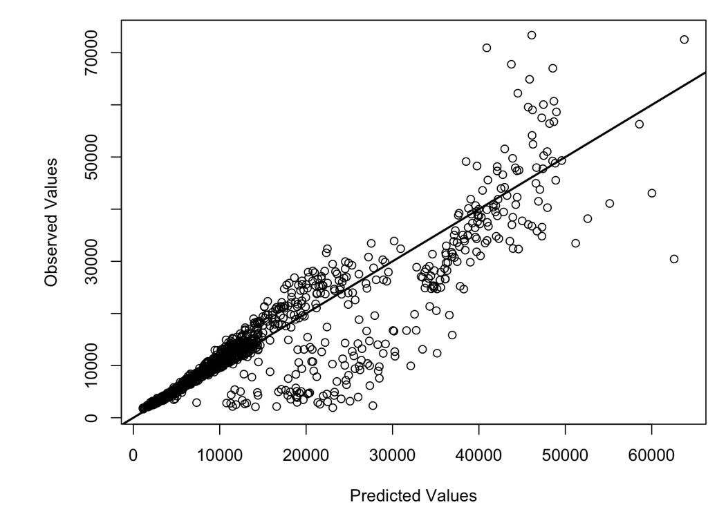

```r
# Insurance charge costs, not percentages
par(mar = c(4, 6, 1, 0.1))
plot(prediction_table$V1, prediction_table$fit, xlab = "Predicted Values", ylab = "Observed Values")
abline(a = 0, b = 1, lwd = 2)
```